# Data 607 Project 3

Inna Yedzinovich, Zaneta Paulusova, Md Asaduzzaman, Md. Asadul, Md. Simon Chowdhury

2024-11-03

## Introduction

For this project we focused on answering the question “What are the most valued data science skills?”.

Our approach to answering this question involved creating a survey to identify five valuable data science skills as perceived by survey respondents. We then compared these findings to the article titled “Data Science Skills Survey 2022 – By AIM and Great Learning.” In this article, we focused on a table that lists common skills desired by recruiters, categorized by years of experience. We will adjust the data to ensure the skills align with one another. Additionally, we will calculate the mean for the various years of experience columns from the website’s data. Finally, we will combine both datasets into one graph for a comparative analysis of our internal survey results alongside the findings from the website.

#### Tables creation for our data

```r
library(DBI)
library(RMySQL)

user <- Sys.getenv("MYSQL_USER")
password <- Sys.getenv("MYSQL_PASSWORD")
host <- Sys.getenv("MYSQL_HOST")
dbname <- Sys.getenv("MYSQL_DBNAME")

conn <- dbConnect(RMySQL::MySQL(), user = user, password = password, host = host, dbname = dbname)

create_experience_table <- "
CREATE TABLE experience (
  experience_id INT NOT NULL,
  respondent_id INT NULL,
  data_science_experience TINYINT(1) NULL,
  software_engineering_experience TINYINT(1) NULL,
  PRIMARY KEY (experience_id)
);"

create_respondents_table <- "
CREATE TABLE respondents (
  respondent_id INT NOT NULL,
  first_name VARCHAR(45) NULL,
  last_name VARCHAR(45) NULL,
  age INT NULL,
  PRIMARY KEY (respondent_id)
);"

create_interestareas_table <- "
CREATE TABLE interestareas (
  interest_id INT NOT NULL,
  respondent_id INT NULL,
  interest_area VARCHAR(45) NULL,
  PRIMARY KEY (interest_id)
);"

create_softskills_table <- "
CREATE TABLE softskills (
  soft_skill_id INT NOT NULL,
  respondent_id INT NULL,
  soft_skill VARCHAR(45) NULL,
  PRIMARY KEY (soft_skill_id)
);"

create_programminglanguages_table <- "
CREATE TABLE programminglanguages (
  language_id INT NOT NULL,
  respondent_id INT NULL,
  language VARCHAR(45) NULL,
  PRIMARY KEY (language_id)
);"

create_learningresources_table <- "
CREATE TABLE learningresources (
  resource_id INT NOT NULL,
  respondent_id INT NULL,
  resource VARCHAR(45) NULL,
  PRIMARY KEY (resource_id)
);"

create_valuableskills_table <- "
CREATE TABLE valuableskills (
  valuable_skill_id INT NOT NULL,
  respondent_id INT NULL,
  skill_rank INT NULL,
  skill_name VARCHAR(45) NULL,
  PRIMARY KEY (valuable_skill_id)
);"

dbExecute(conn, create_experience_table)
```

```
## [1] 0
```

```r
dbExecute(conn, create_respondents_table)
```

```
## [1] 0
```

```r
dbExecute(conn, create_interestareas_table)
```

```
## [1] 0
```

```r
dbExecute(conn, create_softskills_table)
```

```
## [1] 0
```

```r
dbExecute(conn, create_programminglanguages_table)
```

```
## [1] 0
```

```r
dbExecute(conn, create_learningresources_table)
```

```
## [1] 0
```

```r
dbExecute(conn, create_valuableskills_table)
```

```
## [1] 0
```

```r
dbDisconnect(conn)
```

```
## [1] TRUE
```

This process involves loading a CSV file into R, tidying and normalizing the data, and then loading the cleaned data into a database.

```r
library(dplyr)
library(tidyr)

data <- read.csv("https://raw.githubusercontent.com/simonchy/DATA607/refs/heads/main/week%208/Cleaned_Augmented_Data_Science_Skills.csv")
colnames(data)
```

```
##  [1] "Timestamp"
##  [2] "First.Name.or.Nickname"
##  [3] "List.the.5.most.valuable.data.science.skills..separated.by.commas."
##  [4] "Email.Address"
##  [5] "Age"
##  [6] "Any.data.science.data.analytics.experience."
##  [7] "Any.software.engineering.experience."
##  [8] "Which.programming.languages.do.you.use.most.frequently."
##  [9] "What.resources.do.you.use.for.learning.new.data.science.skills."
## [10] "What.areas.of.data.science.are.you.most.interested.in.learning.more.about."
## [11] "Name..1.most.most.valuable.data.science.skill"
## [12] "Name..2.most.most.valuable.data.science.skill"
## [13] "Name..3.most.most.valuable.data.science.skill"
## [14] "Name..4.most.most.valuable.data.science.skill"
## [15] "Name..5.most.most.valuable.data.science.skill"
## [16] "Which.soft.skill.do.you.think.is.most.important.for.a.data.scientist."
```

```r
colnames(data) <- tolower(colnames(data))

data <- data %>%
  rename(
    timestamp = timestamp,
    first_name = first.name.or.nickname,
    valuable_skills = list.the.5.most.valuable.data.science.skills..separated.by.commas.,
    email = email.address,
    age = age,
    data_science_experience = any.data.science.data.analytics.experience.,
    software_engineering_experience = any.software.engineering.experience.,
    programming_languages = which.programming.languages.do.you.use.most.frequently.,
    learning_resources = what.resources.do.you.use.for.learning.new.data.science.skills.,
    interest_areas = what.areas.of.data.science.are.you.most.interested.in.learning.more.about.,
    skill_1 = name..1.most.most.valuable.data.science.skill,
    skill_2 = name..2.most.most.valuable.data.science.skill,
    skill_3 = name..3.most.most.valuable.data.science.skill,
    skill_4 = name..4.most.most.valuable.data.science.skill,
    skill_5 = name..5.most.most.valuable.data.science.skill,
    soft_skill = which.soft.skill.do.you.think.is.most.important.for.a.data.scientist.
  ) %>%
  mutate(across(everything(), tolower))

# Create respondent_id before separating rows
data <- data %>%
  mutate(respondent_id = row_number())

# Normalize the data
respondents <- data %>%
  select(first_name, age, respondent_id)

experience <- data %>%
  select(data_science_experience, software_engineering_experience, respondent_id) %>%
  mutate(experience_id = row_number())

valuable_skills <- data %>%
  select(skill_1, skill_2, skill_3, skill_4, skill_5, respondent_id) %>%
  pivot_longer(cols = starts_with("skill_"), names_to = "skill_rank", values_to = "skill_name") %>%
  mutate(valuable_skill_id = row_number())

programming_languages <- data %>%
  select(respondent_id, programming_languages) %>%
  separate_rows(programming_languages, sep = ",") %>%
  mutate(language_id = row_number())

learning_resources <- data %>%
  select(respondent_id, learning_resources) %>%
  separate_rows(learning_resources, sep = ",") %>%
  mutate(resource_id = row_number())

interest_areas <- data %>%
  select(respondent_id, interest_areas) %>%
  separate_rows(interest_areas, sep = ",") %>%
  mutate(interest_id = row_number())

soft_skills <- data %>%
  select(soft_skill, respondent_id) %>%
  mutate(soft_skill_id = row_number())

conn <- dbConnect(RMySQL::MySQL(), user = Sys.getenv("MYSQL_USER"), password = Sys.getenv("MYSQL_PASSWORD"), host = Sys.getenv("MYSQL_HOST"), dbname = Sys.getenv("MYSQL_DBNAME"))

# Load the data into the database
dbWriteTable(conn, "respondents", respondents, overwrite = TRUE, row.names = FALSE)
```

```
## [1] TRUE
```

```r
dbWriteTable(conn, "experience", experience, overwrite = TRUE, row.names = FALSE)
```

```
## [1] TRUE
```

```r
dbWriteTable(conn, "valuableskills", valuable_skills, overwrite = TRUE, row.names = FALSE)
```

```
## [1] TRUE
```

```r
dbWriteTable(conn, "programminglanguages", programming_languages, overwrite = TRUE, row.names = FALSE)
```

```
## [1] TRUE
```

```r
dbWriteTable(conn, "learningresources", learning_resources, overwrite = TRUE, row.names = FALSE)
```

```
## [1] TRUE
```

```r
dbWriteTable(conn, "interestareas", interest_areas, overwrite = TRUE, row.names = FALSE)
```

```
## [1] TRUE
```

```r
dbWriteTable(conn, "softskills", soft_skills, overwrite = TRUE, row.names = FALSE)
```

```
## [1] TRUE
```

```r
dbDisconnect(conn)
```

```
## [1] TRUE
```

Let’s demonstrates how to connect to a MySQL database, retrieve data, and visualize it using R.

```r
library(ggplot2)

conn <- dbConnect(RMySQL::MySQL(), user = Sys.getenv("MYSQL_USER"), password = Sys.getenv("MYSQL_PASSWORD"), host = Sys.getenv("MYSQL_HOST"), dbname = Sys.getenv("MYSQL_DBNAME"))
valuable_skills <- dbReadTable(conn, "valuableskills")
dbDisconnect(conn)
```

```
## [1] TRUE
```

```r
skill_counts <- valuable_skills %>%
  count(skill_name, sort = TRUE)
print(skill_counts)
```

```
##                      skill_name  n
## 1               resourcefulness 10
## 2             critical thinking  9
## 3                 data cleaning  9
## 4            data visualization  9
## 5                    creativity  8
## 6                 collaboration  7
## 7                        python  7
## 8          statistical analysis  7
## 9                      teamwork  7
## 10              time management  7
## 11             machine learning  6
## 12                  persistence  6
## 13                          sql  6
## 14                            r  5
```

[output cut: 44 more lines]

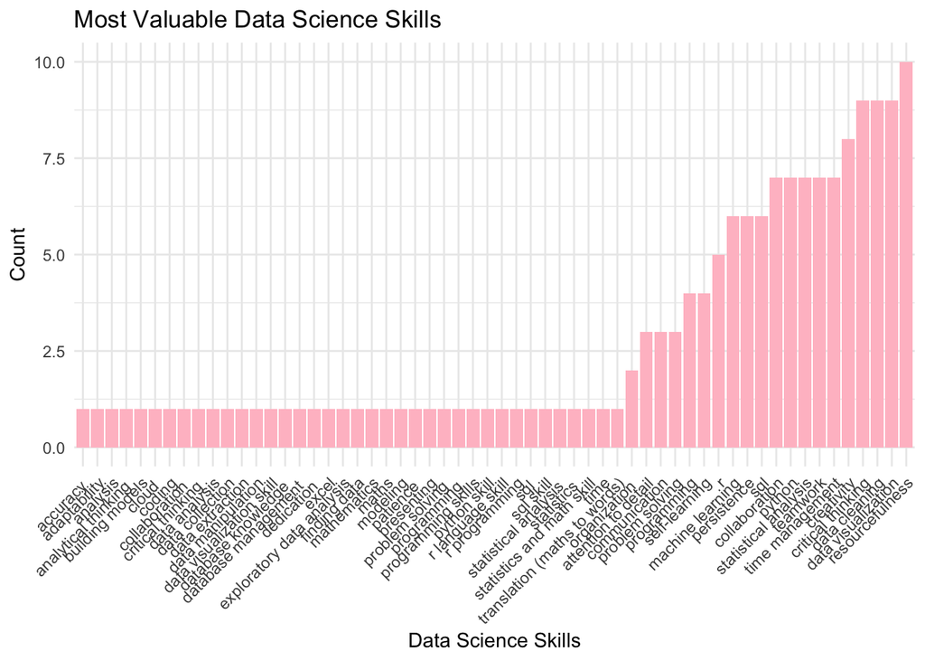

```r
ggplot(skill_counts, aes(x = reorder(skill_name, n), y = n)) +
  geom_bar(stat = "identity", fill = "pink") +
  labs(title = "Most Valuable Data Science Skills", x = "Data Science Skills", y = "Count") +
  theme_minimal() +
  theme(axis.text.x = element_text(angle = 45, hjust = 1))
```

Let’s make it look cleaner:

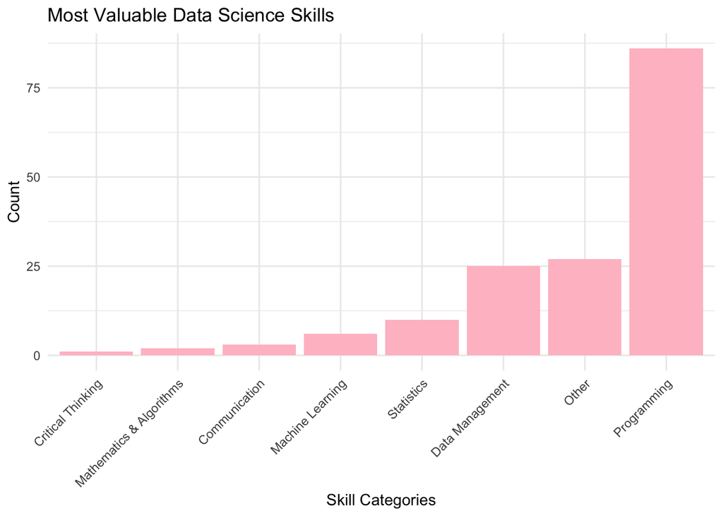

```r
# Group similar skills together using regex grepl
valuable_skills <- valuable_skills %>%
  mutate(skill_group = case_when(
    grepl("machine learning|ML", skill_name, ignore.case = TRUE) ~ "Machine Learning",
    grepl("programming|coding|software|Python|R", skill_name, ignore.case = TRUE) ~ "Programming",
    grepl("statistics|statistical", skill_name, ignore.case = TRUE) ~ "Statistics",
    grepl("data|database", skill_name, ignore.case = TRUE) ~ "Data Management",
    grepl("math|algorithm", skill_name, ignore.case = TRUE) ~ "Mathematics & Algorithms",
    grepl("communication|presentation", skill_name, ignore.case = TRUE) ~ "Communication",
    grepl("teamwork|collaborat", skill_name, ignore.case = TRUE) ~ "Teamwork",
    grepl("critical thinking|problem solving|analysis", skill_name, ignore.case = TRUE) ~ "Critical Thinking",
    TRUE ~ "Other"
  ))

skill_counts <- valuable_skills %>%
  count(skill_group, sort = TRUE)

ggplot(skill_counts, aes(x = reorder(skill_group, n), y = n)) +
  geom_bar(stat = "identity", fill = "pink") +
  labs(title = "Most Valuable Data Science Skills", x = "Skill Categories", y = "Count") +
  theme_minimal() +
  theme(axis.text.x = element_text(angle = 45, hjust = 1))
```

Now, we can compare our results with the findings from the Data Science Skills Survey 2022 by AIM and Great Learning, available at this link.

Below is a table from that website showing the common skills sought by recruiters across different years of experience. The aim is to determine if the skills identified in our internal survey align with those highlighted by recruiters on the website. We will be calculation the mean of the years of experience as we did not request this information on our survey.

```r
common_skills_years <- read.csv("https://raw.githubusercontent.com/ZanetaP02/DATA-607/refs/heads/main/Data%20Science%20Skills%20Survey%202022%20-%20By%20AIM%20and%20Great%20Learning%20-%20Common%20skills%20by%20years%20table.csv")
common_skills_years
```

```
##                               skills less.than.3.years X3.5.years X6.10.years
## 1                   machine learning              81.9       86.8        79.3
## 2                         statistics              79.2       77.4        79.3
## 3               communication skills              68.1       73.6        75.9
## 4              programming knowledge              66.7       75.5        69.0
## 5                 data visualisation              61.1       66.0        62.1
## 6  data wrangling and pre-processing              62.5       49.1        51.7
## 7                    business acumen              37.5       45.3        41.4
## 8                      deep learning              50.0       43.4        51.7
## 9                presentation skills              34.7       37.7        41.4
## 10                  domain expertise              38.9       32.1        27.6
## 11         linear algebra & calculus              33.3       37.7        48.3
## 12                  model deployment              22.2       18.9        20.7
## 13                          big data              36.1       35.8        44.8
##    X10.years
## 1       92.3
## 2       80.8
## 3       80.8
## 4       69.2
## 5       57.7
## 6       53.8
## 7       38.5
## 8       46.2
## 9       38.5
## 10      42.3
## 11      34.6
## 12      30.8
## 13      30.8
```

To streamline data manipulation, first rename the columns for easier reference, then consolidate the different years of experience into a single column.

```r
up_csy <- common_skills_years

colnames(up_csy)[1] <- "skill_group"
colnames(up_csy)[2] <- "less than 3yrs"
colnames(up_csy)[3] <- "3-5yrs"
colnames(up_csy)[4] <- "6-10yrs"
colnames(up_csy)[5] <- "10yrs"

# Print column names to verify
print(colnames(up_csy))
```

```
## [1] "skill_group"    "less than 3yrs" "3-5yrs"         "6-10yrs"
## [5] "10yrs"
```

```r
up_csy1 <- up_csy %>%
  pivot_longer(cols = c('less than 3yrs', '3-5yrs', '6-10yrs', '10yrs'), names_to = "year_experience", values_to = "percentage")

head(up_csy1)
```

```
## # A tibble: 6 × 3
##   skill_group      year_experience percentage
##   <chr>            <chr>                <dbl>
## 1 machine learning less than 3yrs        81.9
## 2 machine learning 3-5yrs                86.8
## 3 machine learning 6-10yrs               79.3
## 4 machine learning 10yrs                 92.3
## 5 statistics       less than 3yrs        79.2
## 6 statistics       3-5yrs                77.4
```

Calculating the mean of the skills

```r
avg_csy <- up_csy1 %>% group_by(skill_group) %>%
  summarise(mean_percentage=mean(percentage),
            .groups = 'drop')
avg_csy
```

```
## # A tibble: 13 × 2
##    skill_group                       mean_percentage
##    <chr>                                       <dbl>
##  1 big data                                     36.9
##  2 business acumen                              40.7
##  3 communication skills                         74.6
##  4 data visualisation                           61.7
##  5 data wrangling and pre-processing            54.3
##  6 deep learning                                47.8
##  7 domain expertise                             35.2
##  8 linear algebra & calculus                    38.5
##  9 machine learning                             85.1
## 10 model deployment                             23.2
## 11 presentation skills                          38.1
## 12 programming knowledge                        70.1
## 13 statistics                                   79.2
```

Grouping skills to match internal survey

```r
avg_csy1 <- avg_csy %>%
 mutate(skill_group = case_when(
    grepl("communication skills", skill_group, ignore.case =TRUE) ~ "Communication",
    grepl("programming knowledge", skill_group, ignore.case =TRUE) ~ "Programming",
    grepl("statistics",  skill_group, ignore.case =TRUE) ~ "Statistics",
    grepl("machine learning",  skill_group, ignore.case =TRUE) ~ "Machine Learning",
    grepl("linear algebra & calculus",  skill_group, ignore.case =TRUE) ~ "Mathematics & Algorithms",
    grepl("big data",  skill_group, ignore.case =TRUE) ~ "Data Management",
    grepl("deep learning",  skill_group, ignore.case =TRUE) ~ "Critical Thinking",
    grepl("data visualisation|business acumen|presentation skills|model deployment|data wrangling and pre-processing|domain expertise",  skill_group, ignore.case =TRUE) ~ "Other",
  ))
avg_csy1
```

```
## # A tibble: 13 × 2
##    skill_group              mean_percentage
##    <chr>                              <dbl>
##  1 Data Management                     36.9
##  2 Other                               40.7
##  3 Communication                       74.6
##  4 Other                               61.7
##  5 Other                               54.3
##  6 Critical Thinking                   47.8
##  7 Other                               35.2
##  8 Mathematics & Algorithms            38.5
##  9 Machine Learning                    85.1
## 10 Other                               23.2
## 11 Other                               38.1
## 12 Programming                         70.1
## 13 Statistics                          79.2
```

Calculating mean of grouping skills to match internal survey skills

```r
avg_skills <- avg_csy1 %>% group_by(skill_group) %>%
  summarise(mean_percentage=mean(mean_percentage),
            .groups = 'drop')
avg_skills
```

```
## # A tibble: 8 × 2
##   skill_group              mean_percentage
##   <chr>                              <dbl>
## 1 Communication                       74.6
## 2 Critical Thinking                   47.8
## 3 Data Management                     36.9
## 4 Machine Learning                    85.1
## 5 Mathematics & Algorithms            38.5
## 6 Other                               42.2
## 7 Programming                         70.1
## 8 Statistics                          79.2
```

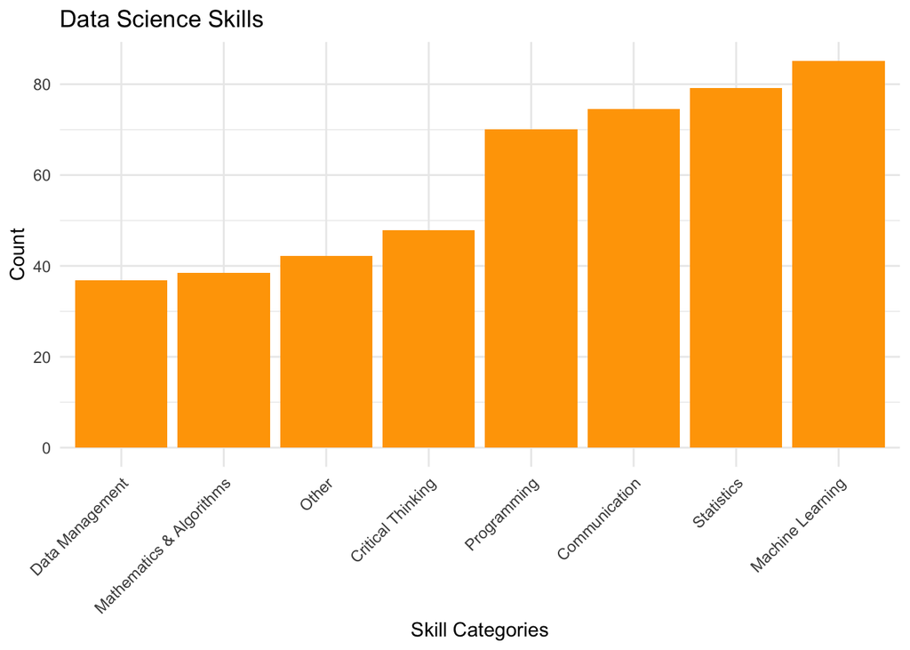

```r
ggplot(avg_skills, aes(x = reorder(skill_group, mean_percentage), y = mean_percentage)) +
  geom_bar(stat = "identity", fill = "orange") +
  labs(title = "Data Science Skills", x = "Skill Categories", y = "Count") +
  theme_minimal() +
  theme(axis.text.x = element_text(angle = 45, hjust = 1))
```

Now, let’s align our survey skills data with the format used on the website by converting the survey results into percentages.

```r
total_count <- sum(skill_counts$n)
total_count
```

```
## [1] 160
```

```r
skill_counts <- skill_counts %>%
  mutate(percentage = (n / total_count) * 100)
skill_counts
```

```
##                skill_group  n percentage
## 1              Programming 86     53.750
## 2                    Other 27     16.875
## 3          Data Management 25     15.625
## 4               Statistics 10      6.250
## 5         Machine Learning  6      3.750
## 6            Communication  3      1.875
## 7 Mathematics & Algorithms  2      1.250
## 8        Critical Thinking  1      0.625
```

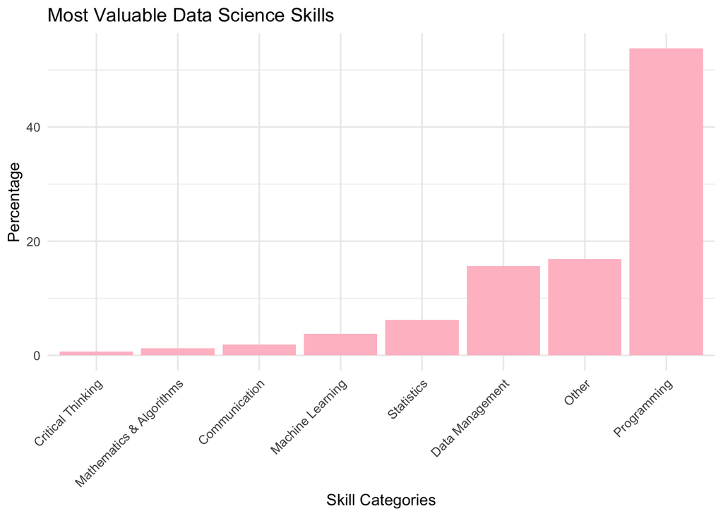

```r
ggplot(skill_counts, aes(x = reorder(skill_group, percentage), y = percentage)) +
  geom_bar(stat = "identity", fill = "pink") +
  labs(title = "Most Valuable Data Science Skills", x = "Skill Categories", y = "Percentage") +
  theme_minimal() +
  theme(axis.text.x = element_text(angle = 45, hjust = 1))
```

Let’s combine the two datasets based on the percentages of the most valued skills.

```r
merged_skill_counts <- avg_skills %>%
  left_join(skill_counts, by = "skill_group")
merged_skill_counts
```

```
## # A tibble: 8 × 4
##   skill_group              mean_percentage     n percentage
##   <chr>                              <dbl> <int>      <dbl>
## 1 Communication                       74.6     3      1.88
## 2 Critical Thinking                   47.8     1      0.625
## 3 Data Management                     36.9    25     15.6
## 4 Machine Learning                    85.1     6      3.75
## 5 Mathematics & Algorithms            38.5     2      1.25
## 6 Other                               42.2    27     16.9
## 7 Programming                         70.1    86     53.8
## 8 Statistics                          79.2    10      6.25
```

```r
merged_skill_counts <- merged_skill_counts %>%
  select(-n) %>%
  rename(
    website = mean_percentage,
    survey = percentage
  )

merged_skill_counts
```

```
## # A tibble: 8 × 3
##   skill_group              website survey
##   <chr>                      <dbl>  <dbl>
## 1 Communication               74.6  1.88
## 2 Critical Thinking           47.8  0.625
## 3 Data Management             36.9 15.6
## 4 Machine Learning            85.1  3.75
## 5 Mathematics & Algorithms    38.5  1.25
## 6 Other                       42.2 16.9
## 7 Programming                 70.1 53.8
## 8 Statistics                  79.2  6.25
```

Convert into the long format:

```r
in_ex_skills <- merged_skill_counts %>%
  pivot_longer(cols = c('website', 'survey'), names_to = "website/survey", values_to = "mean %")
in_ex_skills
```

```
## # A tibble: 16 × 3
##    skill_group              `website/survey` `mean %`
##    <chr>                    <chr>               <dbl>
##  1 Communication            website            74.6
##  2 Communication            survey              1.88
##  3 Critical Thinking        website            47.8
##  4 Critical Thinking        survey              0.625
##  5 Data Management          website            36.9
##  6 Data Management          survey             15.6
##  7 Machine Learning         website            85.1
##  8 Machine Learning         survey              3.75
##  9 Mathematics & Algorithms website            38.5
## 10 Mathematics & Algorithms survey              1.25
## 11 Other                    website            42.2
## 12 Other                    survey             16.9
## 13 Programming              website            70.1
## 14 Programming              survey             53.8
## 15 Statistics               website            79.2
## 16 Statistics               survey              6.25
```

Plot the differences:

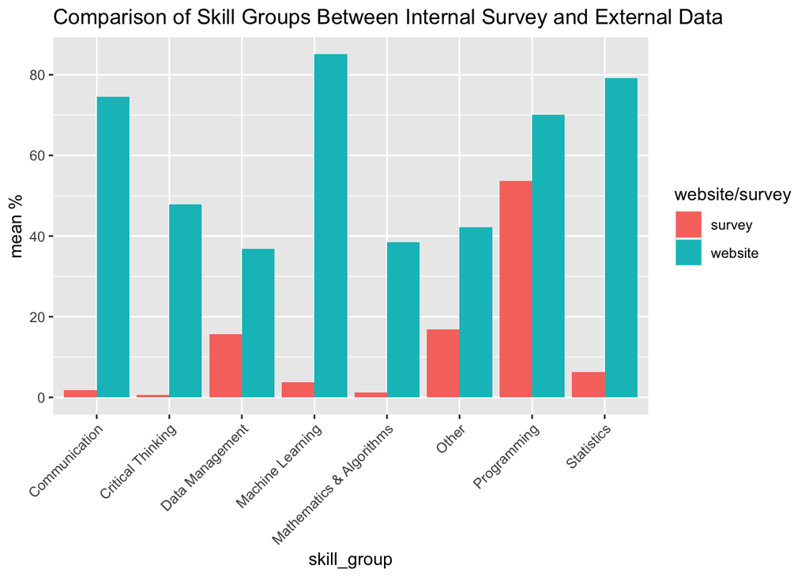

```r
ggplot(in_ex_skills, aes(x = skill_group, y = `mean %`, fill = `website/survey`)) +
  geom_col(position = position_dodge()) +
  ggtitle("Comparison of Skill Groups Between Internal Survey and External Data") +
  theme(axis.text.x = element_text(angle = 45, hjust = 1))
```